# Valutazione controfattuale dell’impatto sanitario da concentrazioni atmosferiche di $NO_2$ ad alta risoluzione spaziale e propagazione dell’incertezza.

Il caso studio della Regione Veneto

Massimo Bressan

2026-09-08

# Project Work Overview

## Obiettivo

- valutazione controfattuale di impatto sanitario (VIS) del numero di casi attribuibili (casi di mortalità per cause respiratorie) associati all’esposizione a lungo termine (media annuale) dei livelli ambientali (outdoor) dellw concentrazioni atmosferiche di $NO_2$

## Metodi

- unità di analisi: sezione censuarie in Regione Veneto (ISTAT 2021)
- concentrazioni $NO_2$ da modellistica di dispersione atmosferica in Regione Veneto (serie storica 2019-2025)
- soglia controfattuale di esposizione (no effetti significativi riconosciuti) da letteratura OMS 10 $\mu g~m^{-3}$
- tassi grezzi mortalità di base per cause respiratorie (Codici ICD-10: J00-J99) per Provincia (casi attesi)
- Risk Ratio (OMS/HRAPIE-2, 2025): 1.05 (1.03 - 1.07) per popolazione 30+ in sezioni censuarie
- funzione concentrazione risposta (formula OMS AirQ+) per stima causale determinante ambientale ed esito sanitario

## Risultati

- stima puntuale casi attribuibili (AC) e frazione attribuibile (AF) anno 2025 per Regione Veneto (somma totale casi stimati per sezione)
- bootstrap non parametrico per propagazione statistica incertezza di stima AC e AF

# Formula OMS VIS

**Casi attribuibili ($AC$): quota di casi attesi associati all’inquinamento atmosferico da $NO_2$**

$$AC = N \cdot B \cdot AF$$

- $N$: popolazione target di riferimento (popolazione $30+$)
- $B$: tasso basale grezzo esito sanitario (mortalità per cause respiratorie)

**Frazione attribuibile ($AF$): rapporto casi attribuibili su casi attesi (casi attesi = $N \cdot B$)**

$$AF = \frac{RR - 1}{RR} = 1 - \frac{1}{e^{\beta \cdot \Delta C}} = 1 - e^{-\beta \cdot \Delta C}$$

- $\frac{RR - 1}{RR}$ proporzione dei casi sanitari evitati se l’esposizione viene ridotta sotto la soglia controfattuale
- $e^{\beta \cdot \Delta C}$ *$Rischio Relativo* per il differenziale di concentrazione $\Delta C$
- $\beta = \frac{\ln(RR_{10})}{10}$ coefficiente funzione log-lineare concentrazione-risposta scalato su $10 \ \mu g~m^{-3}$

# Sezioni | popolazione | attesi

## Sezioni censuarie ISTAT 2021

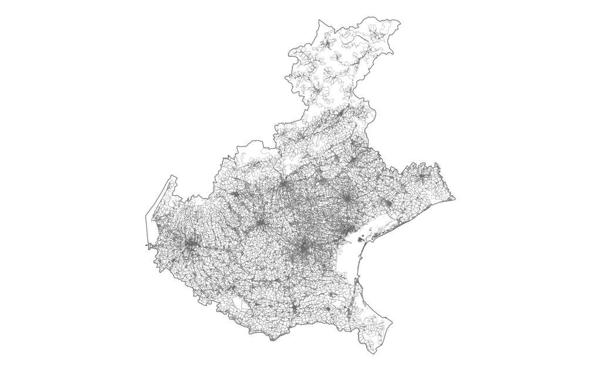

- 43 447 sezioni abitate
- superficie 14 511 km2
- estensione mediana 2.90 ha

## Popolazione classe d’età 30+

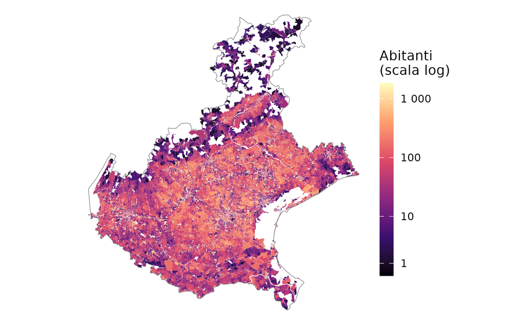

- popolazione totale: 4 847 745 abitanti
- popolazione 30+: 3 521 995 abitanti (73%)
- densità mediana: 13.5 ab/ha

## Casi attesi per sezione

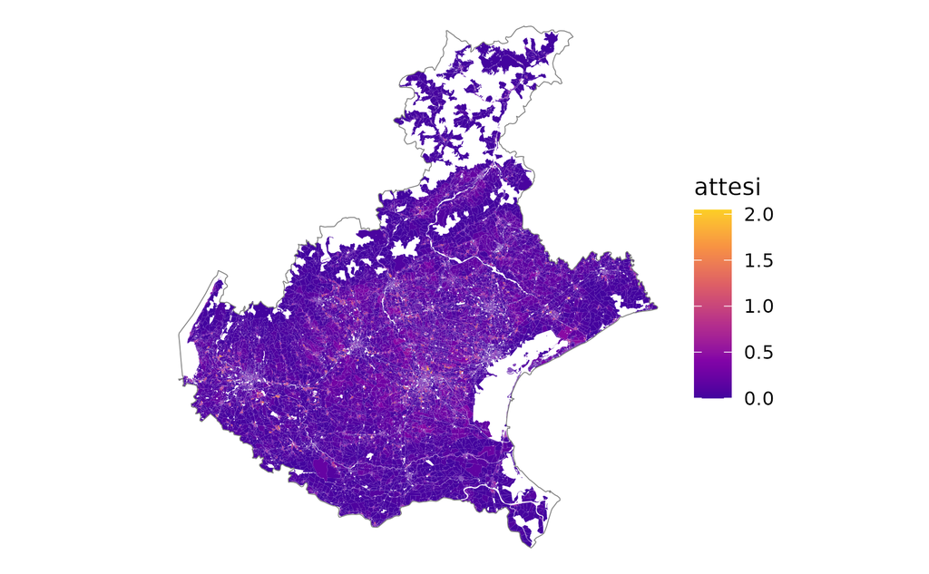

- malattie sistema respiratorio (ICD-10:J00-J99)
- tasso grezzo mortalità provinciale ($B$)
- mortalità media RV: 0.107% (0.084% - 0.140%)
- 107 casi ogni 100 000 abitanti

**Mappatura demografico-attuariale della Regione Veneto**

# Quadro ambientale

## NO2 output modellistica 2019-2025

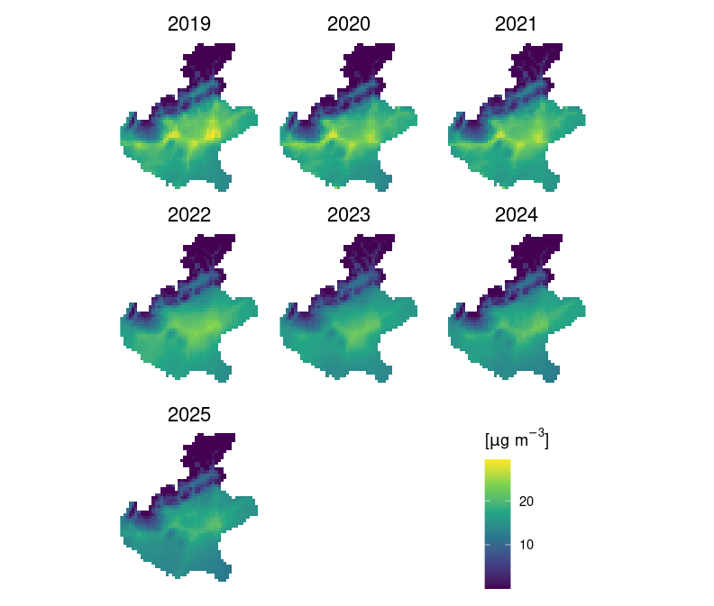

## NO2 boxplot 2019-2025

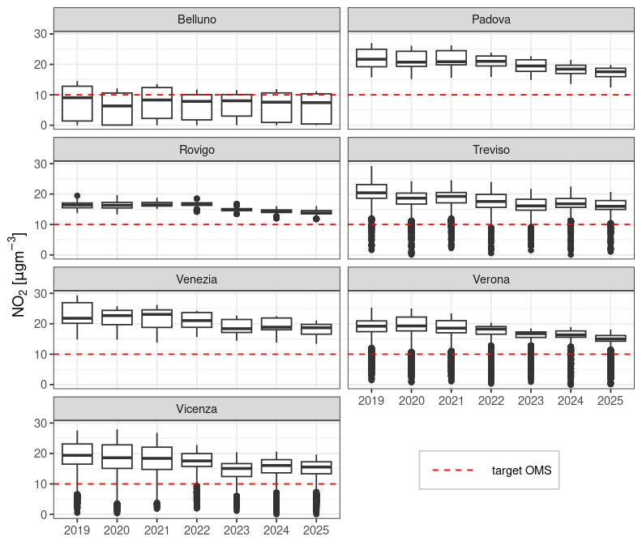

# Concentrazioni ambientali per sezione

## Sezioni censuarie ISTAT 2021

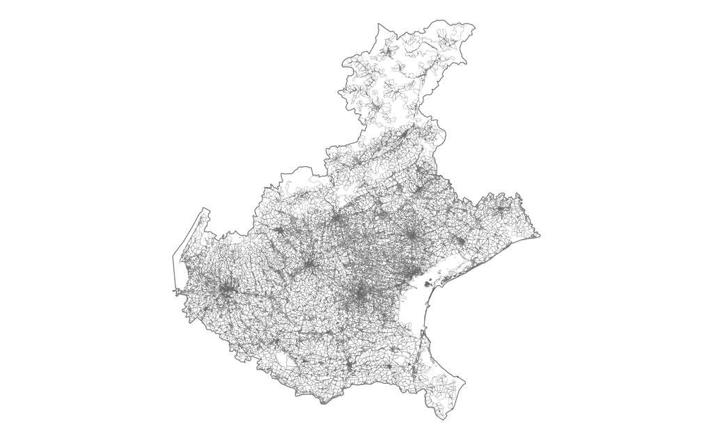

- map overlay disegno sezioni

## $NO_2$ anno 2025

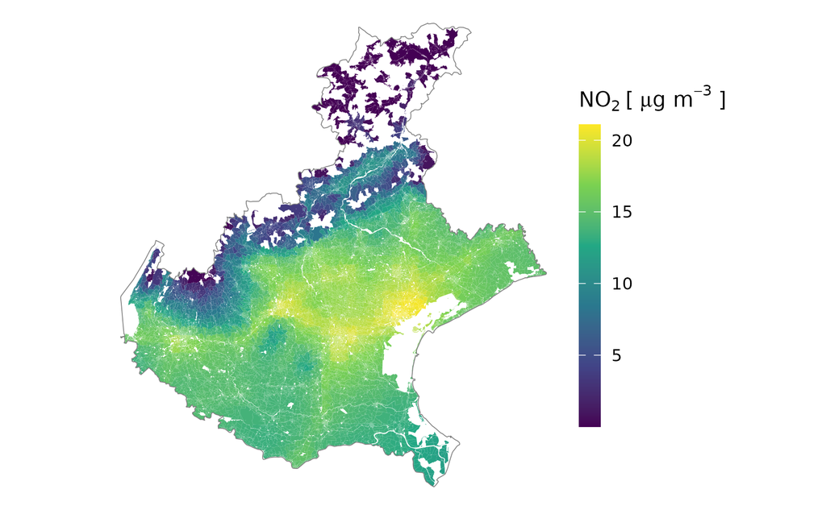

- statistiche zonali $NO_2$ per sezione

## delta $NO_2$ : [2025 - target OMS]

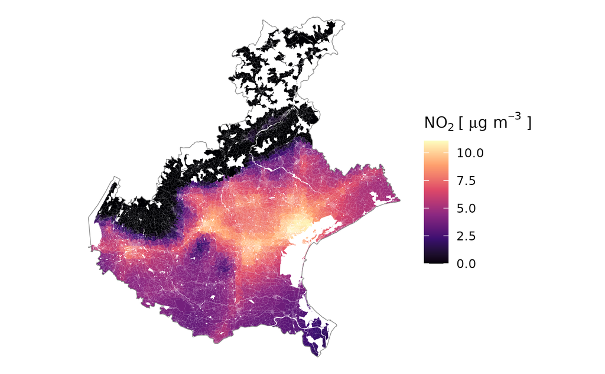

- delta $NO_2$ per sezione

# Esposizione popolazione

## Per Regione

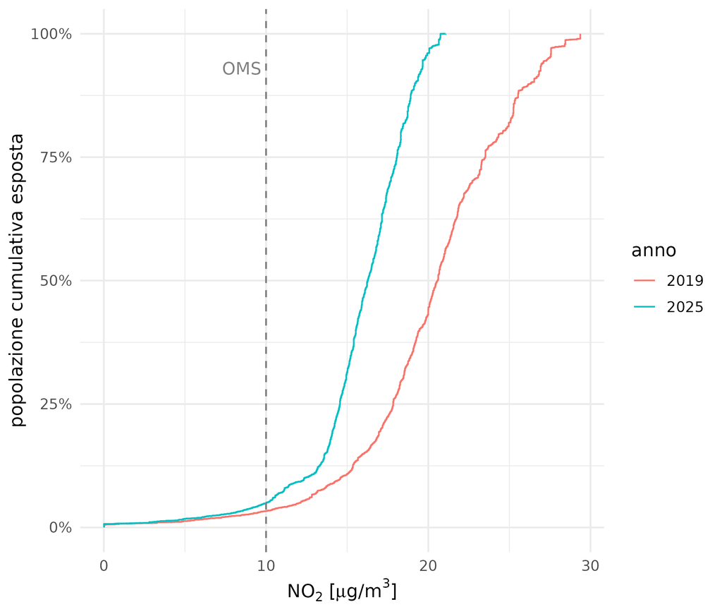

## Per Provincia

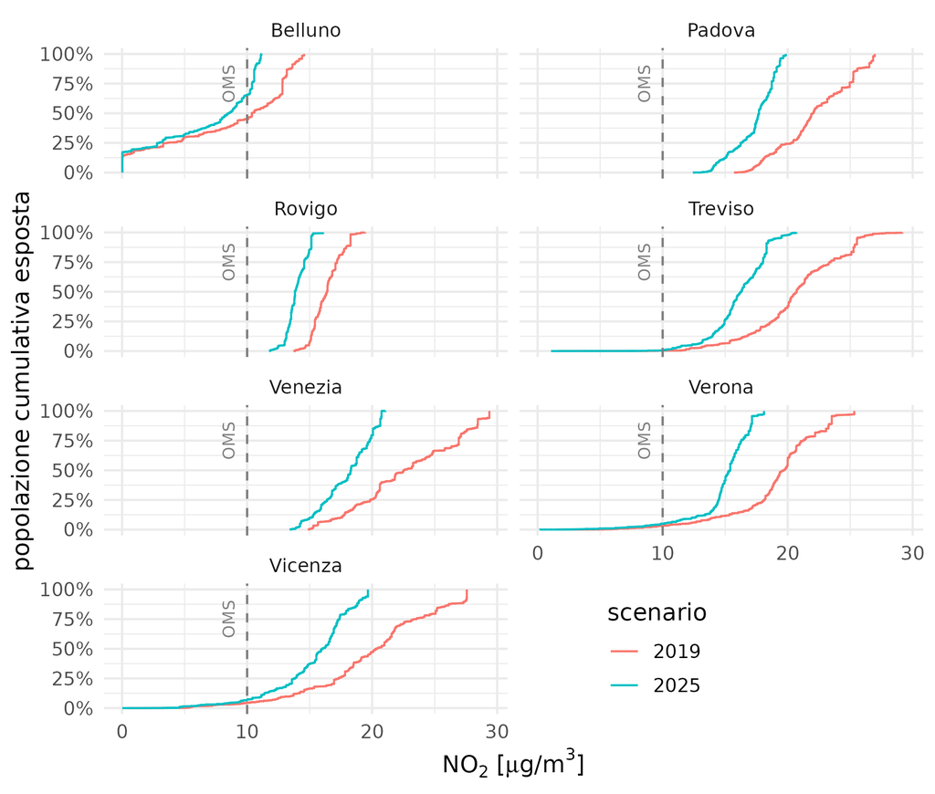

**Confronto con valore controfattuale OMS**